# Manuscript figures

# 5 SNCA-AS1 directionality

## 5.1 Loading data

```r
plot_data <-
  readRDS(here::here("results", "psychencode", "RBD_SNCAAS1_beta_harmonised.Rds")) %>%
  dplyr::rename(
    pvalue_gwas = p.value_1,
    pvalue_eqtl = p.value_2,
    beta_gwas = beta_1,
    beta_eqtl = beta_2
  ) %>%
  dplyr::mutate(
    genome_wide_signif =
      case_when(
        pvalue_gwas < 5e-8 | pvalue_eqtl < 5e-8 ~ "TRUE",
        TRUE ~ "FALSE"
      ) %>%
        fct_relevel(., levels = c("TRUE", "FALSE"))
  )
```

## 5.2 Plot

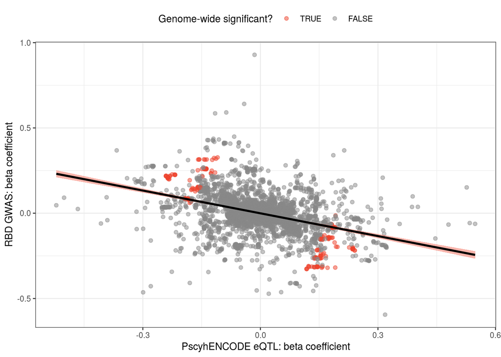

```r
fig <-
  plot_data %>%
  ggplot(aes(x = beta_eqtl, y = beta_gwas)) +
  geom_point(aes(colour = genome_wide_signif), alpha = 0.5) +
  geom_smooth(method = "lm", level = 0.99, colour = "black", fill = "#EE442F") +
  # ggpubr::stat_cor(method = "pearson", cor.coef.name = "R", label.sep = "\n") +
  labs(x = "PscyhENCODE eQTL: beta coefficient", y = "RBD GWAS: beta coefficient") +
  scale_colour_manual(
    values = c("#EE442F", "#888888"),
    name = "Genome-wide significant?"
  ) +
  theme_bw(base_size = theme_base_size) +
  theme(legend.position = "top")

fig
```

#### 5.2.0.1 Figure caption

**Association of RBD risk with SNCA-AS1 expression.** Scatterplot of beta coefficients for SNPs shared between the RBD GWAS and PsychENCODE eQTLs regulating *SNCA-AS1* expression. SNPs passing genome-wide significance (p = 5 x $10^{-8}$) in the RBD GWAS and/or PyschENCODE are indicated in red. The black line represents a linear model fitted for the beta coefficients from either dataset, with the 99% confidence interval indicated with a red fill.

## 5.3 Export files

```r
ggsave("supp_figure_betas.png", fig,
  device = "png",
  path = path_for_figures,
  width = 140,
  height = 120,
  units = "mm",
  dpi = 300,
  limitsize = TRUE
)

ggsave("supp_figure_betas.pdf", fig,
  device = "pdf",
  path = path_for_figures,
  width = 140,
  height = 120,
  units = "mm",
  dpi = 300,
  limitsize = TRUE
)
```